# Lab Lecture - Week 2

## Tidyr

The `tidyr` package contains tools similar to those addressed in the section above on “Data Prep.” However, unlike those `base` functions, the analogs in `tidyr` are easier to understand.

*Supplemental*

- [A Vignette on Tidy Data](https://tidyr.tidyverse.org/articles/tidy-data.html)

### `pivot_wider`

```r
# long to wide
untidy_iris %>%
  pivot_wider(.,
              # the "key" variable(s)
              id_cols = c("ID", "Species"),
              # where the names of the new column come from
              names_from = Petal,
              # where the values for those new columns are from
              values_from = Value) %>%
  head()
```

```
## # A tibble: 6 x 4
##      ID Species Length Width
##   <int> <fct>    <dbl> <dbl>
## 1     1 setosa     1.4   0.2
## 2     2 setosa     1.4   0.2
## 3     3 setosa     1.3   0.2
## 4     4 setosa     1.5   0.2
## 5     5 setosa     1.4   0.2
## 6     6 setosa     1.7   0.4
```

Compare the above chunk to `reshape` below:

```r
reshape(
  # our untidy data
  data = untidy_iris,
  # the "key" variable(s)
  idvar = c("ID", "Species"),
  # the column that needs to change.
  timevar = "Petal",
  # are we adding width to table?
  # or are we adding rows to the table?
  direction = "wide"
)
```

### `pivot_longer`

How about from wide to long?

```r
lob %>%
  pivot_longer(.,
              # the "key" variable(s)
              # Here we use a helper function, starts_with
              # which picks any column starting with 3.
              # alternatively you can type each one of them,
              # eg, c("301", "303", etc)
              # or
              # colnames(.)[2:length(.)]
              cols = starts_with("3"),
              # where the names of the new column come from
              names_to = "Seed",
              # where the values for those new columns are from
              values_to = "height") %>%
  # reorder the columns
  select(height, age, Seed) %>%
  head()
```

```
## # A tibble: 6 x 3
##   height   age Seed
##    <dbl> <dbl> <chr>
## 1   4.51     3 301
## 2   4.55     3 303
## 3   4.79     3 305
## 4   3.91     3 307
## 5   4.81     3 309
## 6   3.88     3 311
```

Compare the above chunk to:

```r
lob2 <- reshape(
  # Wide data
  data = lob,
  # All the columns that need to be dissolved
  varying = names(lob)[2:15],
  # Name of new column with the groupings in `times`
  timevar = "Seed",
  # The groupings of Seed
  times = names(lob)[2:15],
  # the name of the new column for the values
  # that previously had no descriptor (just 301, etc)
  v.names = "height",
  # From wide to long.
  direction = "long"
)
```

## ggplot2

Data visualization is never easy in R and there are several different graphics packages for R, often differing based on the type of R object you’re trying to visualize. With this said, `ggplot2` is one of the more important graphics packages in R, and it is part of the `tidyverse`.

### One Discrete Variable

#### Box Plot

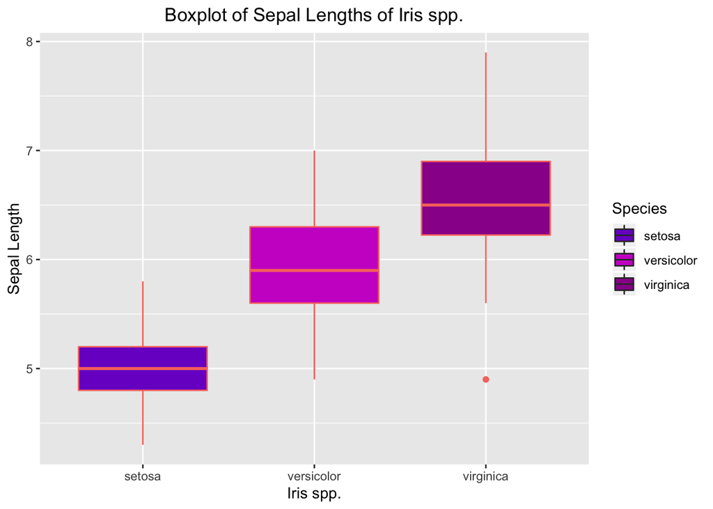

```r
# data
iris %>%
  # call ggplot function
  # data = iris (hence the period)
  # x axis is Species (discrete variable in this case)
  # y axis is Sepal.Length
  # fill in the plot by Species (pick colors later)
  # Line color
  ggplot(data = .,
         mapping = aes(x = Species,
                       y = Sepal.Length,
                       fill = Species,
                       color = "#cc0066")) +
  # Make a boxplot
  geom_boxplot() +
  # Pick colors for fill.
  # color values in "Hexadecimal," see Supplemental below.
  scale_fill_manual(values=c("#7a00cc",
                             "#cc00cc",
                             "#990099")) +
  # Re-label axes.
  labs(title = "Boxplot of Sepal Lengths of Iris spp.",
       y = "Sepal Length",
       x = "Iris spp.") +
  # Adjust legend: remove line color item.
  guides(colour = "none") +
  # Center the title.
  theme(plot.title = element_text(hjust = 0.5))
```

#### Bar Plot

Differing from historgrams, bar plots are used where the x-axis is composed of discrete categories (much like box plots)

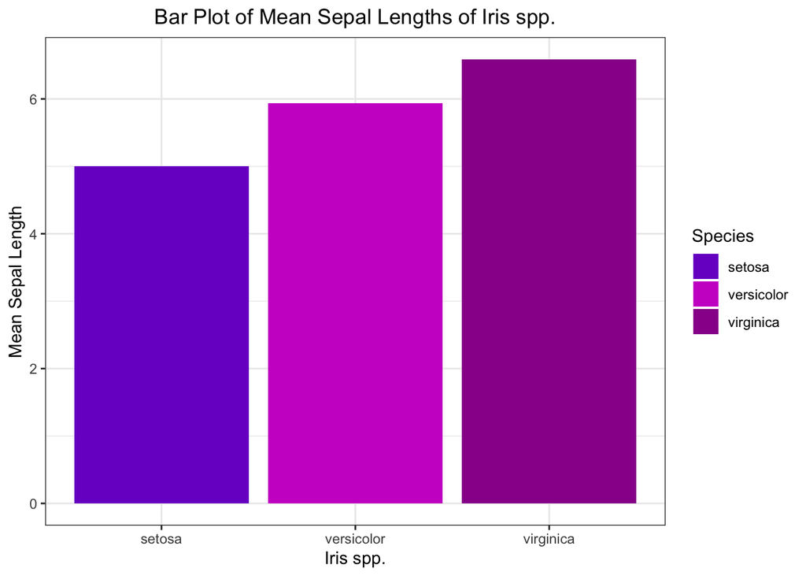

```r
# data
iris %>%
  # call ggplot function
  # data = iris (hence the period)
  # x axis is Species (discrete variable in this case)
  # y axis is Sepal.Length
  # fill in the plot by Species
  ggplot(data = .,
         mapping = aes(x = Species,
                       y = Sepal.Length,
                       fill = Species)) +
  # Make a bar plot
  # Here we tell it to use a summary statistic.
  # Specifically, use the summary stat "mean" on y axis.
  geom_bar(stat = "summary",
           fun.y = mean) +
  # Pick colors for fill.
  # color values in "Hexadecimal," see Supplemental below.
  scale_fill_manual(values=c("#7a00cc",
                             "#cc00cc",
                             "#990099")) +
  # Re-label axes.
  labs(title ="Bar Plot of Mean Sepal Lengths of Iris spp.",
       y = "Mean Sepal Length",
       x = "Iris spp.") +
  # Black and White background
  theme_bw() +
  # Center the title.
  theme(plot.title = element_text(hjust = 0.5))
```

### One Continous Variable

#### Histogram

Let’s look at frequency of measurements of Sepal Lengths for Iris setosa.

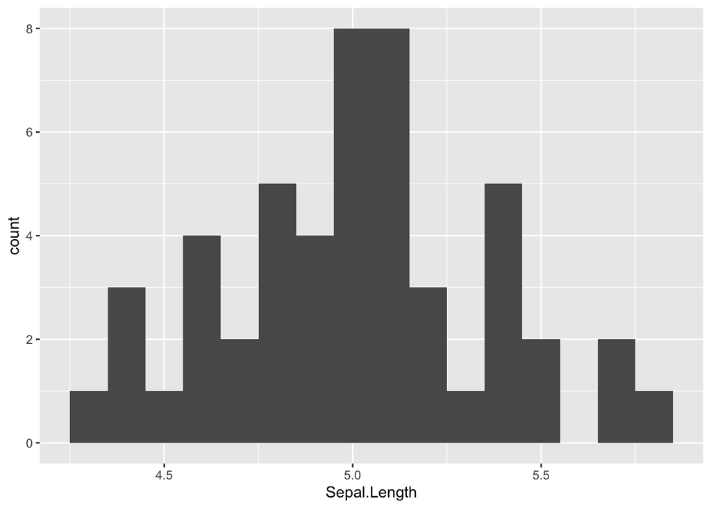

```r
iris %>%
  filter(Species == "setosa") %>%
  ggplot(data = .,
         mapping = aes(x = Sepal.Length)) +
  geom_histogram(binwidth = 0.1)
```

#### Frequency Polygons

Below is a close relative histograms, frequency polygons.

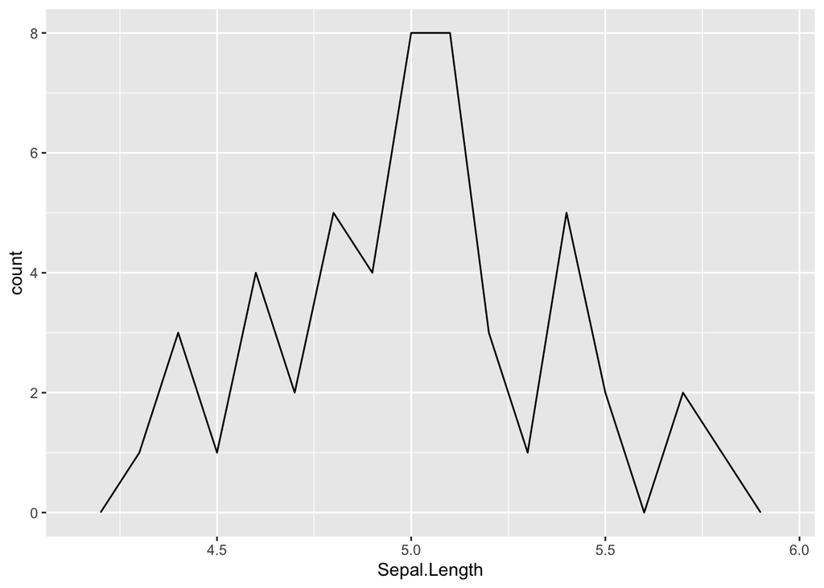

```r
iris %>%
  filter(Species == "setosa") %>%
  ggplot(data = .,
         mapping = aes(x = Sepal.Length)) +
  geom_freqpoly(binwidth = 0.1)
```

### Two Variables

Let’s see if there is a relationship between Sepal Length and Petal Length.

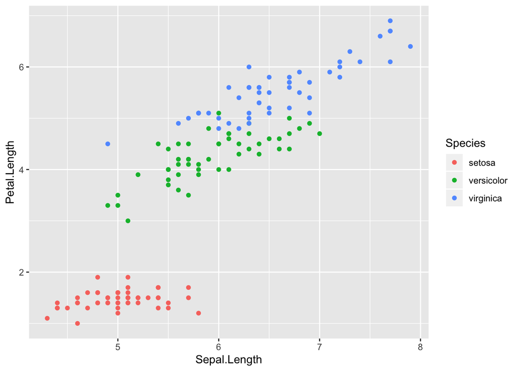

```r
iris %>%
  ggplot(data = .,
         mapping = aes(x = Sepal.Length,
                       y = Petal.Length,
                       color = Species)) +
  geom_point()
```

### Stacking Graphics

#### Lines & Points

Relationship between Chick’s weight and age.

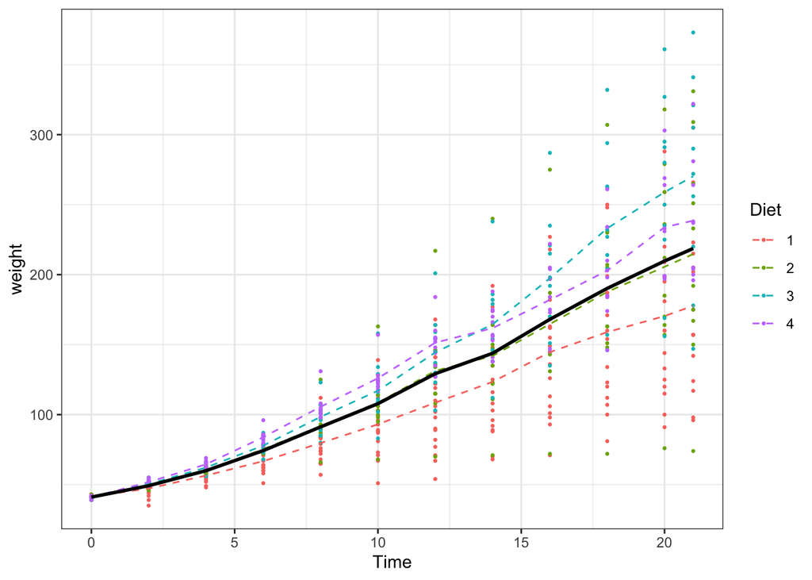

```r
# data
ChickWeight %>%
  # group by Diet
  # NOTE, only general mapping information is provided.
  # As I only want the first two layers to color by Diet.
  # The last line I want just black
  ggplot(data = .,
         mapping = aes(x = Time,
                       y = weight)) +
  # draw points, colored by diet
  # note, most of mapping covered above, but not color.
  geom_point(size = 0.5,
             mapping = aes(color = Diet)) +
  # draw mean for each diet.
  geom_line(stat = "summary",
            fun.y = "mean",
            linetype = "dashed",
            mapping = aes(color = Diet)) +
  # draw overall mean
  # note, we excluded
  geom_line(stat = "summary",
            fun.y = "mean",
            size = 1,
            color = "black") +
  # BW background
  theme_bw()
```

#### Area Plots

Using New York’s 1973 `airquality` dataset. Let’s look at a few variables like Ozone & Temperature by Date.

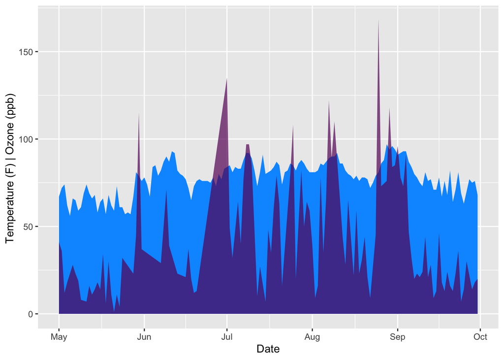

```r
aq %>%
  ggplot(data = .,
         mapping = aes(x = Date)) +
  # Temperature, cerulean
  geom_area(mapping = aes(y = Temp),
            fill = "#0099ff") +
  # Ozone, eggplant
  geom_area(mapping = aes(y = Ozone),
            fill = "#660066",
            alpha = 0.7) +
  labs(y = "Temperature (F) | Ozone (ppb) ")
```

*Supplemental*

- [ggplot2 Cheat Sheet](https://rstudio.com/wp-content/uploads/2015/03/ggplot2-cheatsheet.pdf)
- [ggplot2 Reference](https://ggplot2.tidyverse.org/reference/index.html)
- Need help picking a color? [HTML Color Picker](https://www.w3schools.com/colors/colors_picker.asp)

## The Rest of the Tidyverse

There are other useful `tidyverse` packages that we do not explore here. We can mimic the apply family of functions with `purrr`, maniuplate factors with `forcats`, and perhaps one of the most useful packages we do not cover in depth here is `stringr`, which streamlines a lot issues with maniuplating text and using regular expressions (aka regex). Ever wonder how to extract bits of text from a longer string? You can use regex for that. There are `base` regex functions like `grepl`, but often it’s faster to use `stringr`.